# TET3 in vitro

Loading the necessary libraries:

Notice that the seqLogo library is from the bioconductor package. First install bioconductor, using the commend install.packages(“BiocManager”). Then install the seqLogo package using BiocManager::install(c(“seqLogo”)). Other packages will be installed automatically on request in rstudio if not present already.

```r
library(readxl)
library(tidyr)
library(purrr)
library(dplyr)
library(seqLogo)
options(digits=12)
```

```r
filename <-"../Datasets/mTET3-CpN-FM-Compilation-Forward_kinetics.xlsx"
sheet <- "all"
range1 <- "E26:IY34"
range2 <- "E82:IY83"
range3 <- "E85:IY86"
name <- "mTET3"
```

```r
create_df <- function (filename, sheet, range1, range2, range3,name)
{
  options(digits=10)
  TET <- read_excel(filename, sheet = sheet, range = range1) %>% map_df(rev)
  names(TET)<-paste("seq",1:255)
  TET_v1 <- read_excel(filename, sheet = sheet, range = range2,col_types="text")
  names(TET_v1)<-paste("seq",1:255)
  TET_v2 <- read_excel(filename, sheet = sheet, range = range3,col_types="text")
  names(TET_v2)<-paste("seq",1:255)
  TET_all1 <- rbind(TET,TET_v1,TET_v2)
  TET_all2 <- as.data.frame(t(TET_all1))
}
```

```r
shortlogo <- function(model_simple) {
  mycoeff <- coef(summary(model_simple))
  V3_A <-1
  V3_C <-exp(mycoeff["V3C","Estimate"])
  V3_G <-exp(mycoeff["V3G","Estimate"])
  V3_T <-exp(mycoeff["V3T","Estimate"])
  unV3 <-c(V3_A,V3_C,V3_G, V3_T)
  fact <- sum(c(V3_A,V3_C,V3_G, V3_T))
  myV3 <- unV3/fact
  #
  myV4 <- c(0.0,1.0,0.0,0.0)
  #
  V5_A <-1
  V5_C <-exp(mycoeff["V5C","Estimate"])
  V5_G <-exp(mycoeff["V5G","Estimate"])
  V5_T <-exp(mycoeff["V5T","Estimate"])
  unV5 <-c(V5_A,V5_C,V5_G, V5_T)
  fact <- sum(c(V5_A,V5_C,V5_G, V5_T))
  myV5 <- unV5/fact
  #
  V6_A <-1
  V6_C <-exp(mycoeff["V6C","Estimate"])
  V6_G <-exp(mycoeff["V6G","Estimate"])
  V6_T <-exp(mycoeff["V6T","Estimate"])
  unV6 <-c(V6_A,V6_C,V6_G, V6_T)
  fact <- sum(c(V6_A,V6_C,V6_G, V6_T))
  myV6 <- unV6/fact
  logo_input=data.frame(myV3,myV4,myV5,myV6)
  p <- makePWM(logo_input)
  seqLogo(p, ic.scale=FALSE)
}
```

```r
longlogo <-function(model_complex_sample)
{
  mycoeff <- coef(summary(model_complex_sample))
  #
  V2_A <-1
  V2_C <-exp(mycoeff["V2C","Estimate"])
  V2_G <-exp(mycoeff["V2G","Estimate"])
  V2_T <-exp(mycoeff["V2T","Estimate"])
  unV2 <-c(V2_A,V2_C,V2_G, V2_T)
  fact <- sum(c(V2_A,V2_C,V2_G, V2_T))
  myV2 <- unV2/fact
  #
  V3_A <-1
  V3_C <-exp(mycoeff["V3C","Estimate"])
  V3_G <-exp(mycoeff["V3G","Estimate"])
  V3_T <-exp(mycoeff["V3T","Estimate"])
  unV3 <-c(V3_A,V3_C,V3_G, V3_T)
  fact <- sum(c(V3_A,V3_C,V3_G, V3_T))
  myV3 <- unV3/fact
  #
  myV4 <- c(0.0,1.0,0.0,0.0)
  #
  V5_A <-1
  V5_C <-exp(mycoeff["V5C","Estimate"])
  V5_G <-exp(mycoeff["V5G","Estimate"])
  V5_T <-exp(mycoeff["V5T","Estimate"])
  unV5 <-c(V5_A,V5_C,V5_G, V5_T)
  fact <- sum(c(V5_A,V5_C,V5_G, V5_T))
  myV5 <- unV5/fact
  #
  V6_A <-1
  V6_C <-exp(mycoeff["V6C","Estimate"])
  V6_G <-exp(mycoeff["V6G","Estimate"])
  V6_T <-exp(mycoeff["V6T","Estimate"])
  unV6 <-c(V6_A,V6_C,V6_G, V6_T)
  fact <- sum(c(V6_A,V6_C,V6_G, V6_T))
  myV6 <- unV6/fact
  #
  V7_A <-1
  V7_C <-exp(mycoeff["V7C","Estimate"])
  V7_G <-exp(mycoeff["V7G","Estimate"])
  V7_T <-exp(mycoeff["V7T","Estimate"])
  unV7 <-c(V7_A,V7_C,V7_G, V7_T)
  fact <- sum(c(V7_A,V7_C,V7_G, V7_T))
  myV7 <- unV7/fact
  logo_input=data.frame(myV2,myV3,myV4,myV5,myV6,myV7)
  p <- makePWM(logo_input)
  seqLogo(p, ic.scale=FALSE)
}
```

## read in the data

```r
TET=create_df(filename, sheet, range1, range2, range3,name)
```

```
## * ...
```

[output not shown]

```r
TET$V9 <-as.numeric(as.character(TET$V9))
TET$V10 <-as.numeric(as.character(TET$V10))
```

## Compare the two experimental repeats

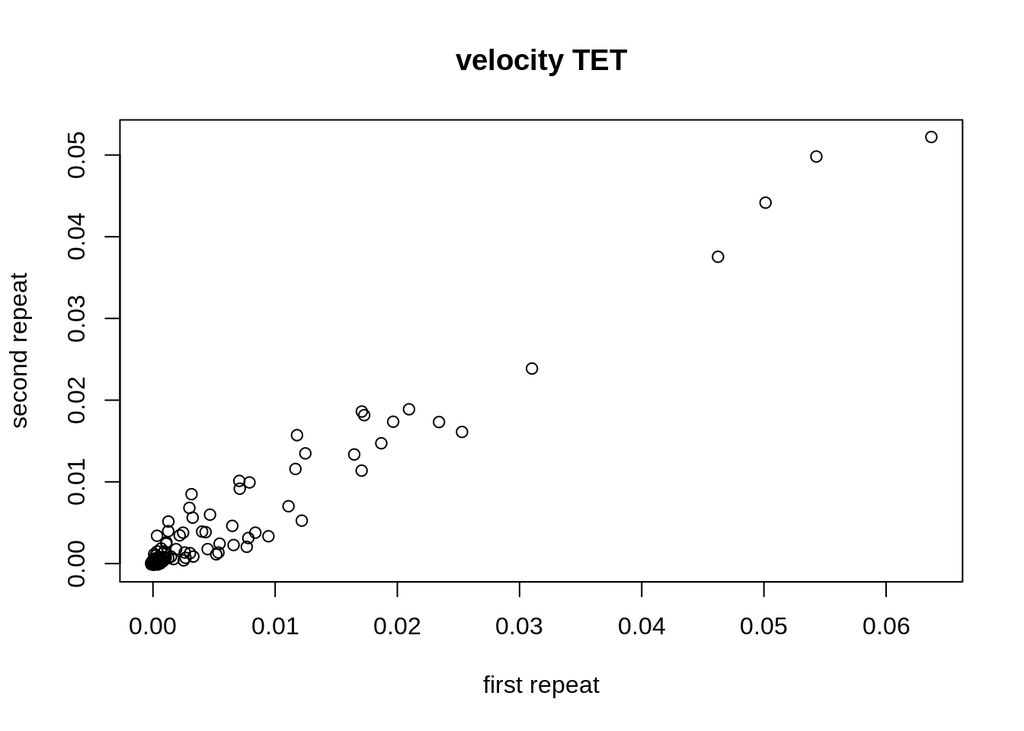

```r
options(digits=8)
plot(TET$V9,TET$V10,main="velocity TET", xlab="first repeat",ylab="second repeat")
```

## Remove negative or extremely low velocities

```r
TET_clean <- TET %>% drop_na()  %>% filter(V9>exp(-12)) %>% filter(V10>exp(-12))
TET_clean <- TET_clean %>% mutate(logV9=log(V9), logV10=log(V10))
TET_clean <- TET_clean %>% mutate(avlogV=(logV9+logV10)/2)
TET_clean <- TET_clean %>% mutate(difflogV=abs(logV9-logV10))
head(TET_clean)
```

```
##       V1 V2 V3 V4 V5 V6 V7 V8            V9           V10      logV9     logV10
## seq 1  A  T  T  C  G  C  C  C 0.00013566112 1.4238136e-04 -8.9053505 -8.8570015
## seq 3  C  G  C  C  C  T  T  T 0.00767614512 2.0514966e-03 -4.8696378 -6.1891857
## seq 4  G  C  C  C  T  T  T  G 0.00010872707 5.1498157e-04 -9.1266698 -7.5713795
## seq 5  G  G  G  C  T  G  C  T 0.00025739156 8.6524929e-05 -8.2649121 -9.3550780
## seq 6  C  T  G  C  T  G  G  A 0.00012814334 6.2691962e-05 -8.9623611 -9.6772773
## seq 7  G  G  A  C  C  T  T  T 0.00094185834 1.4765360e-03 -6.9676557 -6.5180565
##           avlogV    difflogV
## seq 1 -8.8811760 0.048349078
## seq 3 -5.5294118 1.319547915
## seq 4 -8.3490246 1.555290304
## seq 5 -8.8099950 1.090165929
## seq 6 -9.3198192 0.714916266
## seq 7 -6.7428561 0.449599184
```

## Compare log velocities

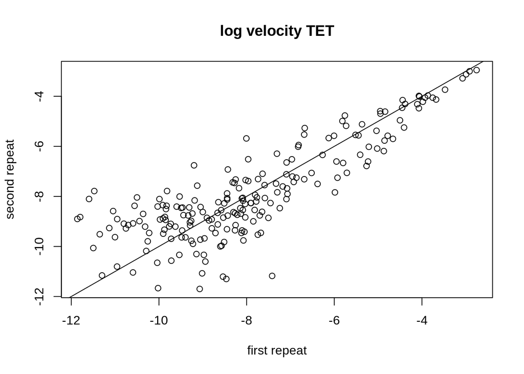

```r
plot(TET_clean$logV9,TET_clean$logV10,main="log velocity TET", xlab="first repeat",ylab="second repeat")
abline(a=0,b=1)
```

Notice that the error here looks like it could well be random

```r
cor(TET_clean$logV9,TET_clean$logV10)
```

```
## [1] 0.83793495
```

## Build a model with three contributing bases and weighting (and C)

```r
model_simple <-lm(avlogV~V3+V5+V6,data=TET_clean,weights=1/(difflogV+0.1))
summary(model_simple)
```

```
##
## Call:
## lm(formula = avlogV ~ V3 + V5 + V6, data = TET_clean, weights = 1/(difflogV +
##     0.1))
##
## Weighted Residuals:
##      Min       1Q   Median       3Q      Max
## -6.23525 -0.92395 -0.14618  0.78855  6.18874
##
## Coefficients:
##             Estimate Std. Error  t value  Pr(>|t|)
## (Intercept) -6.98145    0.25057 -27.8617 < 2.2e-16 ***
## V3C         -0.79011    0.22625  -3.4921 0.0005927 ***
## V3G         -1.96341    0.21860  -8.9817 2.283e-16 ***
## V3T         -1.92995    0.23777  -8.1168 5.296e-14 ***
## V5C          0.62269    0.23039   2.7028 0.0074835 **
## V5G          3.59675    0.23134  15.5475 < 2.2e-16 ***
## V5T         -0.69552    0.26652  -2.6096 0.0097677 **
## V6C         -1.16495    0.23089  -5.0455 1.032e-06 ***
## V6G         -0.39129    0.22791  -1.7168 0.0875965 .
## V6T          0.05019    0.24117   0.2081 0.8353601
## ---
## Signif. codes:  0 '***' 0.001 '**' 0.01 '*' 0.05 '.' 0.1 ' ' 1
##
## Residual standard error: 1.5458 on 195 degrees of freedom
## Multiple R-squared:  0.74234,    Adjusted R-squared:  0.73045
## F-statistic: 62.423 on 9 and 195 DF,  p-value: < 2.22e-16
```

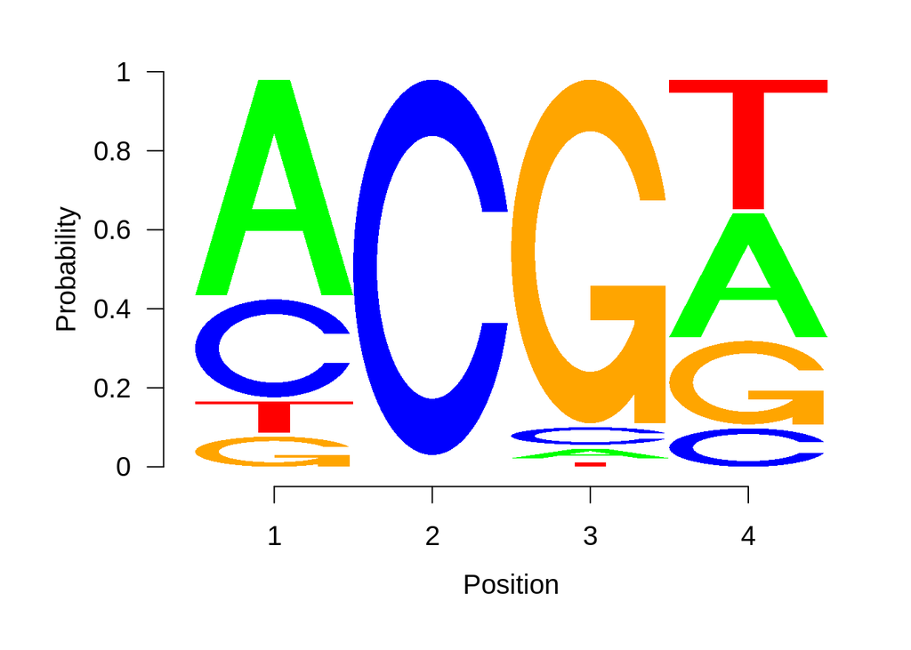

```r
shortlogo(model_simple)
```

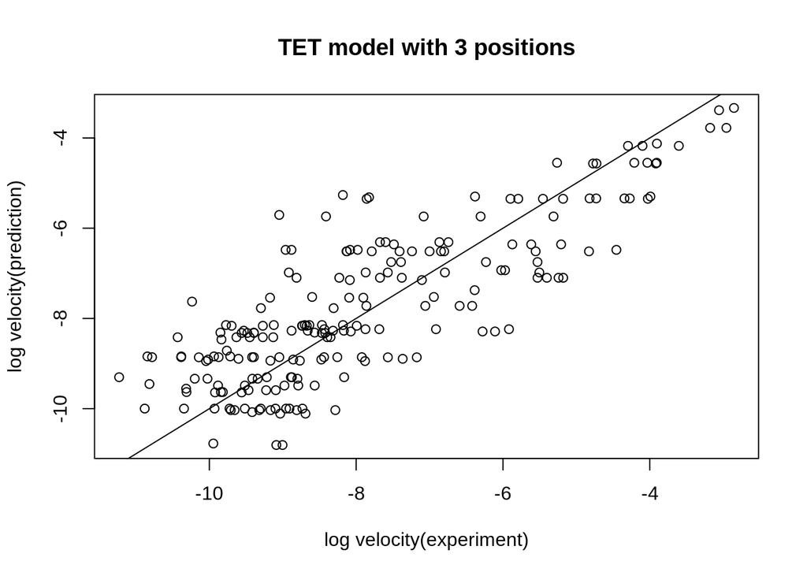

```r
plot(TET_clean$avlogV,as.vector(model_simple$fitted.values),
     main="TET model with 3 positions",
     xlab="log velocity(experiment)",
     ylab="log velocity(prediction)"
     )
abline(a=0,b=1)
```

```r
cor(TET_clean$avlogV,as.vector(model_simple$fitted.values))
```

```
## [1] 0.81939717
```

## Create a model with five contributing bases and weighting

```r
model_complex <-lm(avlogV~V2+V3+V5+V6+V7,data=TET_clean, weights=1/(difflogV+0.1))
summary(model_complex)
```

```
##
## Call:
## lm(formula = avlogV ~ V2 + V3 + V5 + V6 + V7, data = TET_clean,
##     weights = 1/(difflogV + 0.1))
##
## Weighted Residuals:
##      Min       1Q   Median       3Q      Max
## -6.79726 -0.83324 -0.02505  0.72842  6.13514
##
## Coefficients:
##              Estimate Std. Error  t value  Pr(>|t|)
## (Intercept) -7.455108   0.351000 -21.2396 < 2.2e-16 ***
## V2C          0.437706   0.233343   1.8758 0.0622237 .
## V2G          0.636533   0.250216   2.5439 0.0117613 *
## V2T          0.121310   0.262747   0.4617 0.6448278
## V3C         -0.766973   0.220765  -3.4742 0.0006354 ***
## V3G         -1.967218   0.212458  -9.2593 < 2.2e-16 ***
## V3T         -1.881614   0.240918  -7.8102 3.830e-13 ***
## V5C          0.511582   0.229536   2.2288 0.0270079 *
## V5G          3.692857   0.226728  16.2876 < 2.2e-16 ***
## V5T         -0.716326   0.259613  -2.7592 0.0063640 **
## V6C         -1.323348   0.233726  -5.6620 5.493e-08 ***
## V6G         -0.427926   0.231866  -1.8456 0.0665179 .
## V6T         -0.057369   0.243885  -0.2352 0.8142855
## V7C          0.067440   0.245812   0.2744 0.7841107
## V7G          0.010272   0.251220   0.0409 0.9674277
## V7T          0.657362   0.264005   2.4900 0.0136388 *
## ---
## Signif. codes:  0 '***' 0.001 '**' 0.01 '*' 0.05 '.' 0.1 ' ' 1
##
## Residual standard error: 1.4978 on 189 degrees of freedom
## Multiple R-squared:  0.76553,    Adjusted R-squared:  0.74692
## F-statistic: 41.139 on 15 and 189 DF,  p-value: < 2.22e-16
```

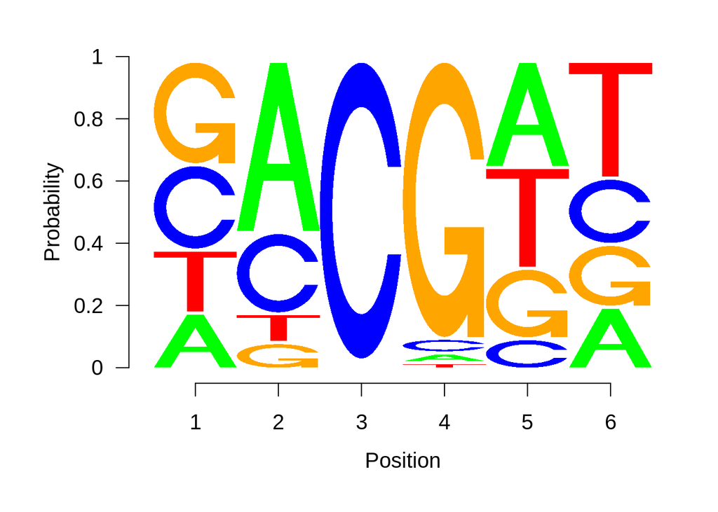

```r
longlogo(model_complex)
```

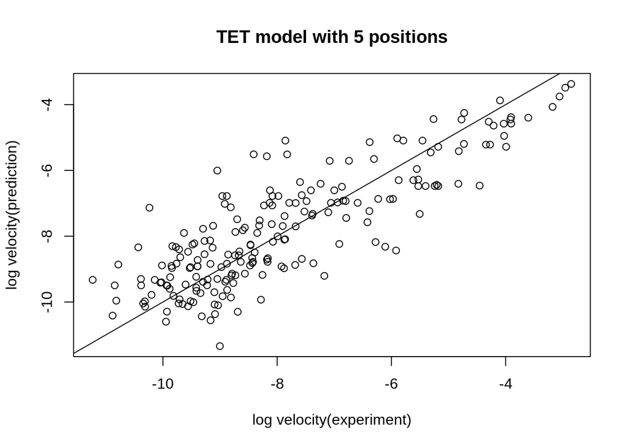

```r
plot(TET_clean$avlogV,as.vector(model_complex$fitted.values),
     main="TET model with 5 positions",
     xlab="log velocity(experiment)",
     ylab="log velocity(prediction)")
abline(a=0,b=1)
```

```r
cor(TET_clean$avlogV,as.vector(model_complex$fitted.values))
```

```
## [1] 0.84225835
```

## Create a model with five contributing bases and weighting, half the data for model

TET_clean_2a will be used to generate the model TET_clean_2b will be used to check the model

```r
ind <- sample(c(TRUE, FALSE), nrow(TET_clean), replace=TRUE, prob=c(0.5, 0.5))
TET_clean_2a<-TET_clean[ind,]
TET_clean_2b<-TET_clean[!ind,]
```

Now build the model with 5 positions and weighting, based on TET_clean_2a

```r
model_complex_sample <-lm(avlogV~V2+V3+V5+V6+V7,data=TET_clean_2a, weights=1/(difflogV+0.1))
summary(model_complex_sample)
```

```
##
## Call:
## lm(formula = avlogV ~ V2 + V3 + V5 + V6 + V7, data = TET_clean_2a,
##     weights = 1/(difflogV + 0.1))
##
## Weighted Residuals:
##      Min       1Q   Median       3Q      Max
## -4.94805 -0.79505 -0.17149  0.66922  4.98396
##
## Coefficients:
##              Estimate Std. Error  t value  Pr(>|t|)
## (Intercept) -7.106704   0.487776 -14.5696 < 2.2e-16 ***
## V2C          1.053989   0.324154   3.2515  0.001584 **
## V2G          0.788912   0.339548   2.3234  0.022267 *
## V2T          0.164095   0.354101   0.4634  0.644117
## V3C         -1.198882   0.284262  -4.2175 5.595e-05 ***
## V3G         -2.298331   0.305964  -7.5118 3.022e-11 ***
## V3T         -1.928994   0.315455  -6.1150 2.079e-08 ***
## V5C          0.270886   0.316789   0.8551  0.394626
## V5G          3.782398   0.299434  12.6318 < 2.2e-16 ***
## V5T         -0.544241   0.358744  -1.5171  0.132534
## V6C         -1.532622   0.306154  -5.0060 2.518e-06 ***
## V6G         -0.646426   0.307132  -2.1047  0.037928 *
## V6T          0.079299   0.346514   0.2288  0.819475
## V7C         -0.353554   0.332234  -1.0642  0.289920
## V7G         -0.184346   0.345886  -0.5330  0.595288
## V7T          0.513216   0.355679   1.4429  0.152298
## ---
## Signif. codes:  0 '***' 0.001 '**' 0.01 '*' 0.05 '.' 0.1 ' ' 1
##
## Residual standard error: 1.4409 on 96 degrees of freedom
## Multiple R-squared:  0.80922,    Adjusted R-squared:  0.77941
## F-statistic: 27.146 on 15 and 96 DF,  p-value: < 2.22e-16
```

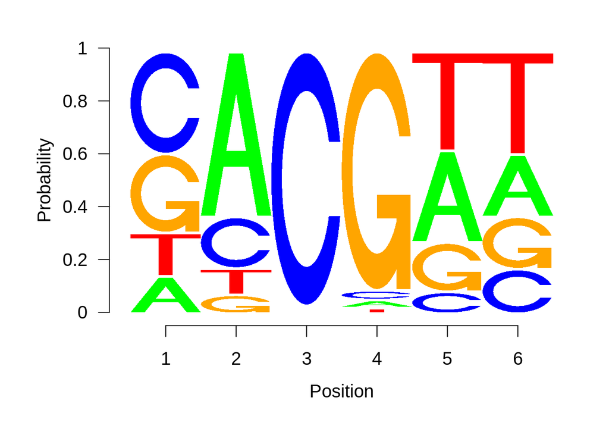

```r
longlogo(model_complex_sample)
```

check how well the model fits the data that have been used for its calculation

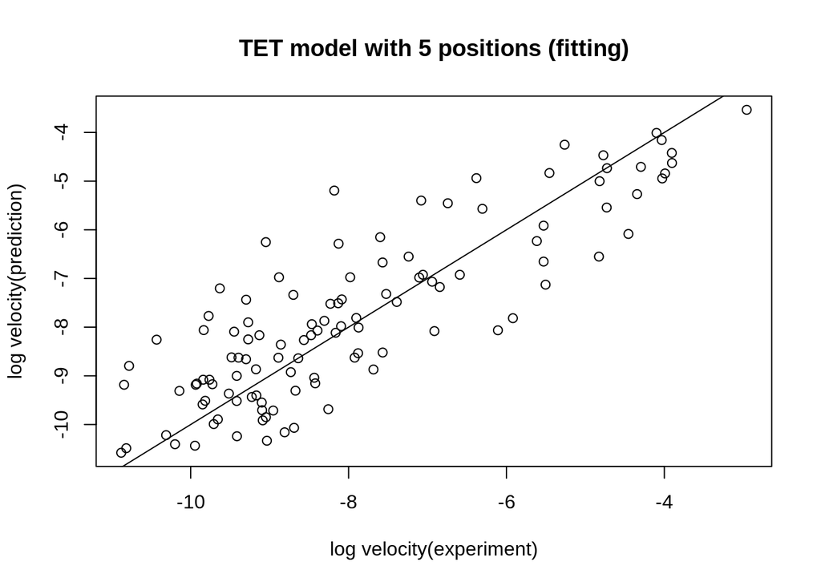

```r
plot(TET_clean_2a$avlogV,predict(model_complex_sample,TET_clean_2a),
     main="TET model with 5 positions (fitting)",
     xlab="log velocity(experiment)",
     ylab="log velocity(prediction)")
abline(a=0,b=1)
```

```r
cor(TET_clean_2a$avlogV,predict(model_complex_sample,TET_clean_2a))
```

```
## [1] 0.85019457
```

check the quality of the model with the other half of the data

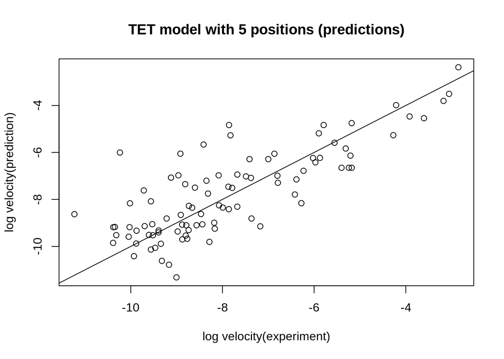

```r
plot(TET_clean_2b$avlogV,predict(model_complex_sample,TET_clean_2b),
     main="TET model with 5 positions (predictions)",
     xlab="log velocity(experiment)",
     ylab="log velocity(prediction)")
abline(a=0,b=1)
```

```r
cor(TET_clean_2b$avlogV,predict(model_complex_sample,TET_clean_2b))
```

```
## [1] 0.7974067
```